# R + tidyr (Data Wrangling)

Mohamed Hassan

11 February 2026

# Workshop goals

By the end of this workshop you should be able to:

- understand **tidy data** and why it matters for data analysis
- clean and wrangle data using **dplyr** (filter, select, mutate, summarise)
- reshape data using **tidyr** (`pivot_longer()`, `pivot_wider()`, `separate()`)
- combine datasets using **joins** (`right_join()`, `left_join()`, `inner_join()`, `anti_join()`)
- handle real messy cases: missing values, wrong column types, messy IDs, duplicate keys

# Getting started

## Installing R and RStudio

- [R:](https://cran.rstudio.com/) https://cran.rstudio.com/
- [RStudio:](https://www.rstudio.com/products/rstudio/download/) https://www.rstudio.com/products/rstudio/download/

Working with R is primarily text-based. The basic mode of use for R is that the user types in a command in the R language and presses enter, and then R computes and displays the result.

[figure not shown]

### RStudio

We will be working in [RStudio](https://www.rstudio.com/products/rstudio/download/). This surrounds the *console*, where one enters commands and views the results, with various conveniences. In addition to the console, RStudio provides panels containing:

- A *text editor*, where R commands can be recorded for future reference.
- A history of commands that have been typed on the console.
- An “environment” panel with a list of *variables*, which contain values that R has been told to save from previous commands.
- A file manager.
- Help on the functions available in R (Using a question mark before the function)
- A panel to show plots (graphs).

[figure not shown]

## R script vs RMD (Markdowns and Notebooks)

- To start an R script click `ctrl + shift + N` or `cmd + shift + N` on mac You can run lines of code, but the output won’t be saved
- To start an RMD click `ctrl + B/N` or `cmd + B/N` on mac to initialize a notebook  
  Allows you to run and visualize output in the file, easy to share with collaborators showing both the code and all results/plots

This is called the main chunk, where is has all the settings that you would like to apply along the notebook

```r
knitr::opts_chunk$set(echo = T, results = "show")
options(width=80)
require("knitr")
## To change the directory in a notebook/markdown
# opts_knit$set(root.dir = "path/to/directory/")
```

To insert a chunk, use `ctrl + alt + I`, or `command + option + I`

# R Basics

## The console

Open RStudio, click on the “Console” panel, type `3+2` and press enter. R displays the result of the calculation. In this document, we will be showing such an interaction with R as below.

```r
3 + 2
```

```
[1] 5
```

`+` is called an operator. R has other operators for basic mathematical calculations:  
`-` for subtraction  
`*` for multiplication  
`/` forward slash for division  
`^` hat for “power”

`*` has higher precedence than `+`. We can use brackets `( )`, if necessary. Try `1+2*3` and `(1+2)*3`

```r
1+2*3
```

```
[1] 7
```

```r
(1+2)*3
```

```
[1] 9
```

Making lines of code according to styler, highlight the lines of code, click `ctrl + shift + A` or `cmd + shift + A`

## Comparisons

We use `>`, `<`, `>=`, `==`, `<=`, `!=` for comparisons. Note that for comparisons its always a double sign to be used. This returns a “logical” value of `TRUE` or `FALSE`.

```r
3 * 3 == 9
```

```
[1] TRUE
```

This literally means Is the left hand side equal to the right hand side? Is 3 times 3 equal to 9?

## Variables

A variable is a name that stores a value. We create a variable by assigining a value to it using `<-` which points to the left assigning the value of the right to the one on the left

```r
weight_kg = 65
weight_kg <- 65
```

To print the value stored in a variable, print the variable

```r
weight_kg
```

```
[1] 65
```

Names of the variables should not contain special characters or spaces, should not start with a number. Dots are ok, unlike many other programming languages

To list all variables in an environment

```r
ls()
```

```
[1] "weight_kg"
```

```r
## to remove a variable/object
rm(weight_kg)

## to remove some variable of a certain pattern (starting/ending/including ....)
rm(list = ls(pattern = ""))
```

Any line of code inside a chunk or in the console that has a `#` before, is a comment. Useful to document your code so its easy to remember why we used this command

To add a `#` at the beginning of the line for multiple lines, highlight all lines, and click `ctrl + shift + c` or `cmd + shift + c`

We can do arithemtic on the variable

```r
weight_kg <- 65
2.2 * weight_kg
```

```
[1] 143
```

## Vectors

A vector is a collection of elements (numbers, words,.. etc) To be able to combine elements into a vector, we use the function c() which stands for combine or concatenate

```r
c(1,2,3,4)
```

```
[1] 1 2 3 4
```

```r
vec <- c(10,20,30,40)
vec + 1 # Here the arithmetic + 1 is applied on every element of the vector
```

```
[1] 11 21 31 41
```

We can also combine vectors

```r
vec + vec
```

```
[1] 20 40 60 80
```

```r
# In this case, the 1st element of vec is added to the 1st element of vec, 2nd with 2nd.. and so on
```

To check the length of the vector we use the function length()

```r
length(vec)
```

```
[1] 4
```

## Data types in R

Most common data types in R are mainly:  
* Numeric (could be double which is the default, or integer)  
* Character (String)  
* Logical (TRUE/FALSE)

To check the type of a vector, we use typeof() function

```r
x <- 5
typeof(x)
```

```
[1] "double"
```

```r
## To create an integer add L to the number
x <- 5L
typeof(x)
```

```
[1] "integer"
```

```r
print(x)
```

```
[1] 5
```

```r
class(x)
```

```
[1] "integer"
```

For Characters, we use single or double quotes

```r
"Hello World"
```

```
[1] "Hello World"
```

```r
plain_txt = 'This is a string'
print(plain_txt)
```

```
[1] "This is a string"
```

```r
typeof(plain_txt)
```

```
[1] "character"
```

```r
class(plain_txt)
```

```
[1] "character"
```

To be able to look for and modify a pattern, the vector should be a string!

There are also categorical vectors in which elements can be one of several “categories/levels”

```r
factor(c("mutant", "wildtype", "mutant"),
       levels = c("wildtype", "mutant"))
```

```
[1] mutant   wildtype mutant
Levels: wildtype mutant
```

Factor is important for arrangement of data in a plot for example.

## Accessing elements of vectors (Indexing)

To access elements, we use [] with a number (index)

```r
vec[1]
```

```
[1] 10
```

```r
vec[-1]
```

```
[1] 20 30 40
```

```r
vec[c(1,3)]
```

```
[1] 10 30
```

```r
vec[1:4]
```

```
[1] 10 20 30 40
```

```r
vec[1] <- 6
```

We can use a vector instead of numbers to index a vector

```r
myindex <- c(4,2,1,3)
vec[myindex]
```

```
[1] 40 20  6 30
```

```r
## which is the same as
vec[c(4,2,1,3)]
```

```
[1] 40 20  6 30
```

## Matrix

2-D tabular data structure in which all elements are of the same type (typically numeric matrices, but could also be character or logical)

```r
# To create a matrix
matrix()
```

```
     [,1]
[1,]   NA
```

```r
# Example:
mat <- matrix(1:12, nrow = 2, ncol = 6, byrow = F)
mat
```

```
     [,1] [,2] [,3] [,4] [,5] [,6]
[1,]    1    3    5    7    9   11
[2,]    2    4    6    8   10   12
```

```r
typeof(mat)
```

```
[1] "integer"
```

```r
class(mat)
```

```
[1] "matrix" "array"
```

```r
# To get the dimensions of a matrix
dim(mat)
```

```
[1] 2 6
```

```r
## get only how many rows
nrow(mat)
```

```
[1] 2
```

```r
## get only how many columns
ncol(mat)
```

```
[1] 6
```

```r
## get column names
colnames(mat)
```

```r
## Accessing elements of a matrix
mat[1,3] # row number, # col number]
```

```
[1] 5
```

```r
# this retuns the element at row 1, column 3
```

## Data frame

Similar to a matrix, the difference is that the columns of a dataframe could be of different types (could combine numeric values, strings, logical) The index of each row could be from 1 to length(dataframe) or could have a unique name (can be accessed/modified using rownames function)

## Functions

a function is followed by parentheses () mean(), sd(), print(), rep()

```r
# To create a function
name_of_function <- function(){ # inside parentheses what the function takes
  # what the function should do
}

## then call the function
name_of_function()
```

The function takes arguments (options), some are mandatory and some are optional. Arguments can be supplied in order (positional argument), or by the argument name (better to use). Clicking `tab` for autocompletion helps us remember what arguments a function could take

```r
calc <- function(num1, num2){
  sum = num1 + num2
  print(sum)
}

calc(num1 = 10, 5)
```

```
[1] 15
```

## Lists

Lists can contain different kinds of elements

```r
mylist <- list(num= 42, greeting="Hello, World")

# to access elements: ## double square bracket to access
mylist[[1]]
```

```
[1] 42
```

```r
mylist$greeting
```

```
[1] "Hello, World"
```

If you are not sure about the type of a variable, run class

```r
class(vec)
```

```
[1] "numeric"
```

```r
class(mat)
```

```
[1] "matrix" "array"
```

```r
str(mylist)
```

```
List of 2
 $ num     : num 42
 $ greeting: chr "Hello, World"
```

### Applying a function on a list (very practical)

```r
list_nums <- list(
  a = c(1, 2, 3),
  b = c(10, 20, 30),
  c = c(5, 5, 5)
)

lapply(list_nums, mean)
```

```
$a
[1] 2

$b
[1] 20

$c
[1] 5
```

### Applying an anonymous function (when we want to perform many steps over the list)

```r
list_nums_modified <- lapply(list_nums, function(element){
  ## first do this on each element
  element + 4
  ## then do this
  return(element)
})
```

```r
## Applying the mean function over a list
lapply(list_nums, function(elem) elem^2) ## returns a list
```

```
$a
[1] 1 4 9

$b
[1] 100 400 900

$c
[1] 25 25 25
```

### sapply (simple apply)

for a simplified version

```r
sapply(list_nums, function(elem) elem^2) ## returns a simplified form (vector)
```

```
     a   b  c
[1,] 1 100 25
[2,] 4 400 25
[3,] 9 900 25
```

## Loops

```r
for (numb in list_nums){
  print(numb)
}
```

```
[1] 1 2 3
[1] 10 20 30
[1] 5 5 5
```

## If conditional

```r
list_nums <- c(1,2,3,6,7)
for(numb in list_nums){
  if(numb > 5){
    print(numb)}
    else print("This number is smaller than 5, so will not be printed")
}
```

```
[1] "This number is smaller than 5, so will not be printed"
[1] "This number is smaller than 5, so will not be printed"
[1] "This number is smaller than 5, so will not be printed"
[1] 6
[1] 7
```

# Tidy data

Tidy data rules: 1. Each variable = one column 2. Each observation = one row 3. Each type of entity = one table

Why it matters: - easier plotting - easier modelling - fewer bugs - compatible with tidyverse grammar

## Installing packages

To install a package from [CRAN](https://cran.r-project.org/), we use the function install.packages

```r
install.packages("styler")
install.packages("tidyverse")
```

### From Github

[Github](https://github.com) is a web-based platform for version control, collaboration, and code sharing, built around the Git system. It allows users to track changes to files, manage contributions from multiple people, and publish open-source projects.

GitHub is widely used for:

- Sharing R packages before they are published on CRAN
- Developing packages collaboratively using pull requests and issues
- Storing analysis projects (scripts, R Markdown, data, documentation)
- Reproducible workflows, since every change is tracked

Installing a package from Github `install_github("author/package")`

[figure not shown]

```r
install.packages("devtools")

## To load a library
library(devtools)
devtools::install_github("githubusername/repository")
install_github("immunogenomics/presto")

## instead of loading a whole package, we can call a function from a package using the format:
package::function()

## function select
AnnotationDbi::select()
dplyr::select()

## Example
devtools::install_github("immunogenomics/presto")
```

### From Bioconductor

[Bioconductor](https://www.bioconductor.org/)

Bioconductor is an open-source project that provides a large collection of R packages for biological and biomedical data analysis, especially high-throughput sequencing, genomics, transcriptomics, and proteomics.

- Curated, peer-reviewed packages: Every package goes through a structured review for code quality, documentation, and reproducibility.
- Focus on life sciences: Tools for RNA-seq, ChIP-seq, single-cell RNA-seq, epigenomics, variant analysis, annotation, and more.
- Reproducible workflows using standardized data structures (e.g., SummarizedExperiment, SingleCellExperiment).
- Frequent release cycle (twice yearly), synchronized with R versions.

Bioconductor has become a central ecosystem for computational biology because it promotes reproducibility, integrates with modern R workflows, and provides consistent interfaces for complex biological datasets.

[figure not shown]

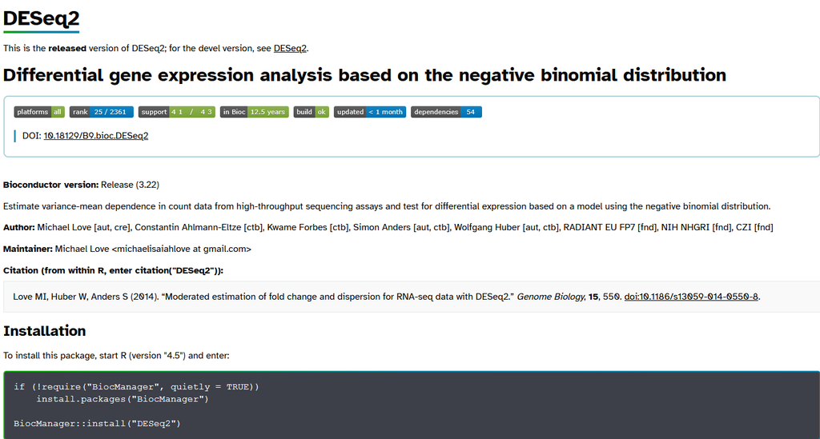

```r
## First, to install Bioconductor
if (!require("BiocManager", quietly = TRUE))
    install.packages("BiocManager")
BiocManager::install(version = "3.22")

## Installing packages from Bioconductor
BiocManager::install("DESeq2")
```

```r
install.packages("tidyverse")
install.packages("janitor")
install.packages("lubridate")
```

## Loading libraries

```r
library(tidyverse)
library(tidyr)
library(dplyr)
library(stringr)
library(readr)
library(janitor)
library(lubridate)

# To load multiple libraries at once, we can use pacman package, p_load function
pacman::p_load(tidyverse, styler, dplyr, stringr, janitor, lubridate)
```

## Working with directories

```r
## To check the current directory
getwd()
## To change the working directory
setwd("Path/to/directory/")

## Remember to change the directory for the whole notebook, we use the main chunk
```

## Importing data

```r
## Importing an R data structure object (.RDS)
myfile <- readRDS(file = "path/to/file.RDS")

## CSV file
myfile <- utils::read.csv()

## More general function
myfile <- utils::read.delim(file = "/path/to/file.extenstion",
                  header = T, sep = "\t") ## the file has a header with column names, and each observation is separated by a tab
myfile <- readxl::read_xlsx("/path/to/file/file.xlsx")
```

## Checking the content of a file

```r
head(myfile) ## shows the first 6 observations, can change n argument
tail(myfile) ## shows the last 6 observations, can change n argument
str(myfile) ## checks the structure of the file as a variable
dim(myfile) ## checks the dimensions of a file (returns number of rows, number of columns)
nrow(myfile) # checks the number of rows
ncol(myfile)# checks the number of columns

## checks the column names
colnames(myfile)
names(myfile)
```

## Data maniuplation

### Adding columns to a dataframe

```r
myfile$newcol <- myfile$col1 * myfile$col2
```

### Access columns by name

```r
# one column
myfile$columnname
## more than a column
myfile[, c("col1", "col4", "col2")]
myfile[, c(1,4,2)]
```

### Access a column by index

```r
myfile[,4] # the row is empty, which means show all rows for column 4
```

### Access rows

```r
df[4, ] ## gets the 4th row for all columns
df[4:10] ## from 4th to 10th
```

### Select rows by a condition (exact)

```r
myfile_subset <- subset(myfile, given_column == "something") ## subset rows that follow this condition
```

### Select rows by a condition (more than one category)

```r
myfile_subset <- subset(myfile,
                        given_column %in% c("something", "something else")) ## subset rows that follow this condition
```

### Select rows by a condition (exclusion of exact)

```r
myfile_subset <- subset(myfile, given_column != "something") ## subset rows that follow this condition
```

### Select rows by a condition (exclusion of more than one category)

```r
myfile_subset <- subset(myfile, given_column != "something" &
         given_column != "something else" &
         given_column != "another thing")
```

Using the `!` to negate

```r
myfile_subset <- subset(myfile,
                        !(given_column %in% c("something", "something else")))
```

There is no equivalent operator for `%in%`, but you can create it!

```r
"%out%" <- Negate("%in%")
```

```r
myfile_subset <- subset(myfile,
                        given_column %out% c("something", "something else"))
## subset rows that do not follow this condition
```

```r
# clean column names
# df <- janitor::clean_names(df)

# install.packages("tidytuesdayR")
# tuesdata <- tidytuesdayR::tt_load('2023-10-24')
# df <- tuesdata$patient_risk_profiles

df <- readxl::read_xlsx("tuesdata_df.xlsx")
head(df)
```

| personId | age group: 10 - 14 | age group: 15 - 19 | age group: 20 - 24 | age group: 65 - 69 | age group: 40 - 44 | age group: 45 - 49 | age group: 55 - 59 | age group: 85 - 89 | age group: 75 - 79 | age group: 5 - 9 | age group: 25 - 29 | age group: 0 - 4 | age group: 70 - 74 | age group: 50 - 54 | age group: 60 - 64 | age group: 35 - 39 | age group: 30 - 34 | age group: 80 - 84 | age group: 90 - 94 | Sex = FEMALE | Sex = MALE | Acetaminophen exposures in prior year | Occurrence of Alcoholism in prior year | Anemia in prior year | Angina events in prior year | ANTIEPILEPTICS in prior year | Occurrence of Anxiety in prior year | Osteoarthritis in prior year | Aspirin exposures in prior year | … |
| --- | --- | --- | --- | --- | --- | --- | --- | --- | --- | --- | --- | --- | --- | --- | --- | --- | --- | --- | --- | --- | --- | --- | --- | --- | --- | --- | --- | --- | --- | --- |
| 1 | 0 | 0 | 0 | 0 | 0 | 0 | 0 | 0 | 0 | 1 | 0 | 0 | 0 | 0 | 0 | 0 | 0 | 0 | 0 | 1 | 0 | 1 | 0 | 0 | 1 | 1 | 0 | 1 | 0 | … |
| 2 | 0 | 0 | 0 | 0 | 0 | 0 | 0 | 0 | 0 | 0 | 0 | 0 | 0 | 0 | 0 | 0 | 0 | 1 | 0 | 0 | 1 | 0 | 0 | 0 | 0 | 1 | 0 | 0 | 0 | … |
| 3 | 0 | 0 | 0 | 0 | 0 | 1 | 0 | 0 | 0 | 0 | 0 | 0 | 0 | 0 | 0 | 0 | 0 | 0 | 0 | 0 | 1 | 0 | 0 | 0 | 0 | 0 | 0 | 0 | 0 | … |
| 4 | 0 | 0 | 0 | 0 | 0 | 0 | 0 | 0 | 0 | 0 | 0 | 0 | 0 | 0 | 0 | 0 | 1 | 0 | 0 | 0 | 1 | 0 | 0 | 0 | 0 | 0 | 1 | 0 | 1 | … |
| 5 | 0 | 0 | 0 | 0 | 0 | 0 | 0 | 0 | 0 | 0 | 0 | 0 | 0 | 0 | 1 | 0 | 0 | 0 | 0 | 1 | 1 | 0 | 0 | 1 | 0 | 1 | 0 | 0 | 0 | … |
| 6 | 0 | 0 | 0 | 0 | 0 | 0 | 0 | 0 | 1 | 0 | 0 | 0 | 0 | 0 | 0 | 0 | 0 | 0 | 0 | 0 | 1 | 0 | 0 | 0 | 0 | 0 | 0 | 0 | 0 | … |

```r
df$`predicted risk of Sudden Vision Loss, with no eye pathology causes`
```

```
  [1] 1.115083e-04 1.607285e-03 1.458917e-04 1.527737e-04 3.258655e-04 4.667266e-04
  [7] 2.140686e-04 1.600603e-04 2.184795e-04 6.122239e-04 1.036383e-04 6.725240e-04
 [13] 3.901209e-05 6.773092e-05 2.323113e-04 9.834800e-05 4.658432e-05 1.349731e-04
 [19] 3.089568e-04 3.136560e-04 6.938989e-05 1.141138e-04 1.059116e-04 3.656749e-04
 [25] 4.289676e-04 1.280323e-04 6.686286e-05 1.063679e-04 2.121934e-04 7.246477e-04
 [31] 9.408668e-05 4.846494e-04 2.092650e-04 3.848392e-04 2.493011e-04 6.565204e-04
 [37] 2.682293e-04 5.494188e-04 1.903225e-04 7.163179e-05 9.823006e-05 2.013026e-04
 [43] 2.274620e-04 1.126852e-04 9.863359e-05 6.779899e-04 3.971666e-05 4.995190e-05
 [49] 5.199037e-05 8.074773e-05 1.597246e-04 5.455884e-04 1.431606e-04 4.426006e-04
 [55] 1.203483e-04 9.213029e-04 1.043975e-04 1.553771e-04 2.758162e-04 2.382385e-04
 [61] 9.461499e-05 1.672590e-04 2.414275e-04 1.585947e-04 3.395669e-04 2.180608e-05
 [67] 1.913146e-04 2.044669e-04 2.813584e-04 9.473806e-05 7.132445e-05 1.358532e-04
 [73] 1.018202e-04 2.385006e-05 4.251972e-05 6.189295e-04 5.478834e-04 9.701396e-04
 [79] 3.324462e-04 2.345282e-04 4.010593e-04 1.223014e-04 1.369716e-04 3.559392e-05
 [85] 2.381193e-05 2.206086e-04 6.609310e-04 6.652940e-05 1.531101e-04 6.950099e-05
 [91] 6.898172e-05 7.661815e-05 4.003384e-04 7.201001e-04 8.395539e-04 1.982071e-04
 [97] 4.538425e-05 5.966995e-04 4.032301e-04 3.110642e-04
```

```r
df <- janitor::clean_names(df)
head(df)
```

| person_id | age_group_10_14 | age_group_15_19 | age_group_20_24 | age_group_65_69 | age_group_40_44 | age_group_45_49 | age_group_55_59 | age_group_85_89 | age_group_75_79 | age_group_5_9 | age_group_25_29 | age_group_0_4 | age_group_70_74 | age_group_50_54 | age_group_60_64 | age_group_35_39 | age_group_30_34 | age_group_80_84 | age_group_90_94 | sex_female | sex_male | acetaminophen_exposures_in_prior_year | occurrence_of_alcoholism_in_prior_year | anemia_in_prior_year | angina_events_in_prior_year | antiepileptics_in_prior_year | occurrence_of_anxiety_in_prior_year | osteoarthritis_in_prior_year | aspirin_exposures_in_prior_year | … |
| --- | --- | --- | --- | --- | --- | --- | --- | --- | --- | --- | --- | --- | --- | --- | --- | --- | --- | --- | --- | --- | --- | --- | --- | --- | --- | --- | --- | --- | --- | --- |
| 1 | 0 | 0 | 0 | 0 | 0 | 0 | 0 | 0 | 0 | 1 | 0 | 0 | 0 | 0 | 0 | 0 | 0 | 0 | 0 | 1 | 0 | 1 | 0 | 0 | 1 | 1 | 0 | 1 | 0 | … |
| 2 | 0 | 0 | 0 | 0 | 0 | 0 | 0 | 0 | 0 | 0 | 0 | 0 | 0 | 0 | 0 | 0 | 0 | 1 | 0 | 0 | 1 | 0 | 0 | 0 | 0 | 1 | 0 | 0 | 0 | … |
| 3 | 0 | 0 | 0 | 0 | 0 | 1 | 0 | 0 | 0 | 0 | 0 | 0 | 0 | 0 | 0 | 0 | 0 | 0 | 0 | 0 | 1 | 0 | 0 | 0 | 0 | 0 | 0 | 0 | 0 | … |
| 4 | 0 | 0 | 0 | 0 | 0 | 0 | 0 | 0 | 0 | 0 | 0 | 0 | 0 | 0 | 0 | 0 | 1 | 0 | 0 | 0 | 1 | 0 | 0 | 0 | 0 | 0 | 1 | 0 | 1 | … |
| 5 | 0 | 0 | 0 | 0 | 0 | 0 | 0 | 0 | 0 | 0 | 0 | 0 | 0 | 0 | 1 | 0 | 0 | 0 | 0 | 1 | 1 | 0 | 0 | 1 | 0 | 1 | 0 | 0 | 0 | … |
| 6 | 0 | 0 | 0 | 0 | 0 | 0 | 0 | 0 | 1 | 0 | 0 | 0 | 0 | 0 | 0 | 0 | 0 | 0 | 0 | 0 | 1 | 0 | 0 | 0 | 0 | 0 | 0 | 0 | 0 | … |

# Using tidyverse

Used for data wrangling and maniuplation

When we load tidyverse, by default, dplyr, readr, stringr, tibble, tidyr, purrr, and ggplot2 are loaded

```r
library(tidyverse)
```

We will work with [care state](https://github.com/rfordatascience/tidytuesday/tree/main/data/2025/2025-04-08) dataset from tidy tuesday

```r
care_state <- readr::read_csv(
  "https://raw.githubusercontent.com/rfordatascience/tidytuesday/main/data/2025/2025-04-08/care_state.csv"
)
care_state %>% glimpse()
```

```
Rows: 1,232
Columns: 8
$ state        <chr> "AK", "AK", "AK", "AK", "AK", "AK", "AK", "AK", "AK", "AK", "AK", "…
$ condition    <chr> "Healthcare Personnel Vaccination", "Healthcare Personnel Vaccinati…
$ measure_id   <chr> "HCP_COVID_19", "IMM_3", "OP_18b", "OP_18b_HIGH_MIN", "OP_18b_LOW_M…
$ measure_name <chr> "Percentage of healthcare personnel who are up to date with COVID-1…
$ score        <dbl> 7.3, 80.0, 140.0, 157.0, 136.0, 136.0, NA, 196.0, 230.0, 182.0, 200…
$ footnote     <chr> NA, NA, "25, 26", "25, 26", "25, 26", "25, 26", "25, 26", "25", "25…
$ start_date   <date> 2024-01-01, 2023-10-01, 2023-04-01, 2023-04-01, 2023-04-01, 2023-0…
$ end_date     <date> 2024-03-31, 2024-03-31, 2024-03-31, 2024-03-31, 2024-03-31, 2024-0…
```

- *state* >> The two-letter code for the state (or territory, etc) where the hospital is located.
- *condition* >> The condition for which the patient was admitted. Six categories of conditions are included in the data.
- *measure_id* >> The ID of the thing being measured. Note that there are 22 unique IDs but only 21 unique names.
- *measure_name* >> The name of the thing being measured. Note that there are 22 unique IDs but only 21 unique names.
- *score* >> The score of the measure.
- *footnote* >> Footnotes that apply to this measure: – 5 = “Results are not available for this reporting period.”, – 25 = “State and national averages include Veterans Health Administration (VHA) hospital data.”, – 26 = “State and national averages include Department of Defense (DoD) hospital data.”.
- *start_date* >> date The date on which measurement began for this measure.
- *end_date* >> date The date on which measurement ended for this measure.

Q1: How many columns are there in the dataset? What columns exist? Q2: How many observations(rows)? Q3: How many different states exist in the dataset ? Q4: What categories are there in the condition column? Q5: What is being measured in the “measure_name” column? Q6: How many observations with footnote 5, 25, and 26? Q7: Which years are there in the start and end date columns?

```r
starwars <- dplyr::starwars
```

```r
head(starwars)
```

| name | height | mass | hair_color | skin_color | eye_color | birth_year | sex | gender | homeworld | species | films | vehicles | starships |
| --- | --- | --- | --- | --- | --- | --- | --- | --- | --- | --- | --- | --- | --- |
| Luke Skywalker | 172 | 77 | blond | fair | blue | 19.0 | male | masculine | Tatooine | Human |  |  |  |
| C-3PO | 167 | 75 | NA | gold | yellow | 112.0 | none | masculine | Tatooine | Droid |  |  |  |
| R2-D2 | 96 | 32 | NA | white, blue | red | 33.0 | none | masculine | Naboo | Droid |  |  |  |
| Darth Vader | 202 | 136 | none | white | yellow | 41.9 | male | masculine | Tatooine | Human |  |  |  |
| Leia Organa | 150 | 49 | brown | light | brown | 19.0 | female | feminine | Alderaan | Human |  |  |  |
| Owen Lars | 178 | 120 | brown, grey | light | blue | 52.0 | male | masculine | Tatooine | Human |  |  |  |

```r
typeof(starwars)
```

```
[1] "list"
```

```r
class(starwars)
```

```
[1] "tbl_df"     "tbl"        "data.frame"
```

```r
## Get the name of all columns
colnames(starwars)
```

```
 [1] "name"       "height"     "mass"       "hair_color" "skin_color" "eye_color"
 [7] "birth_year" "sex"        "gender"     "homeworld"  "species"    "films"
[13] "vehicles"   "starships"
```

```r
# Or
names(starwars)
```

```
 [1] "name"       "height"     "mass"       "hair_color" "skin_color" "eye_color"
 [7] "birth_year" "sex"        "gender"     "homeworld"  "species"    "films"
[13] "vehicles"   "starships"
```

# Functions on rows

## 1. Filtering

`filter(dataframe, condition)` like `filter(dataframe, column == "something")` `filter(dataframe, condition1, condition2)` like `filter(dataframe, column == "something", column == "something")`

**Why it matters in healthcare/bioinformatics:** you almost always filter: - QC failures - non-target tissue / condition - outliers - incomplete cases

```r
human_starwars <- filter(starwars,
                         species == "Human")
head(human_starwars)
```

| name | height | mass | hair_color | skin_color | eye_color | birth_year | sex | gender | homeworld | species | films | vehicles | starships |
| --- | --- | --- | --- | --- | --- | --- | --- | --- | --- | --- | --- | --- | --- |
| Luke Skywalker | 172 | 77 | blond | fair | blue | 19.0 | male | masculine | Tatooine | Human |  |  |  |
| Darth Vader | 202 | 136 | none | white | yellow | 41.9 | male | masculine | Tatooine | Human |  |  |  |
| Leia Organa | 150 | 49 | brown | light | brown | 19.0 | female | feminine | Alderaan | Human |  |  |  |
| Owen Lars | 178 | 120 | brown, grey | light | blue | 52.0 | male | masculine | Tatooine | Human |  |  |  |
| Beru Whitesun Lars | 165 | 75 | brown | light | blue | 47.0 | female | feminine | Tatooine | Human |  |  |  |
| Biggs Darklighter | 183 | 84 | black | light | brown | 24.0 | male | masculine | Tatooine | Human |  |  |  |

```r
filter(starwars,
       species == "Human", height > 180)
```

| name | height | mass | hair_color | skin_color | eye_color | birth_year | sex | gender | homeworld | species | films | vehicles | starships |
| --- | --- | --- | --- | --- | --- | --- | --- | --- | --- | --- | --- | --- | --- |
| Darth Vader | 202 | 136.0 | none | white | yellow | 41.9 | male | masculine | Tatooine | Human |  |  |  |
| Biggs Darklighter | 183 | 84.0 | black | light | brown | 24.0 | male | masculine | Tatooine | Human |  |  |  |
| Obi-Wan Kenobi | 182 | 77.0 | auburn, white | fair | blue-gray | 57.0 | male | masculine | Stewjon | Human |  |  |  |
| Anakin Skywalker | 188 | 84.0 | blond | fair | blue | 41.9 | male | masculine | Tatooine | Human |  |  |  |
| Boba Fett | 183 | 78.2 | black | fair | brown | 31.5 | male | masculine | Kamino | Human |  |  |  |
| Qui-Gon Jinn | 193 | 89.0 | brown | fair | blue | 92.0 | male | masculine | NA | Human |  |  |  |
| Padmé Amidala | 185 | 45.0 | brown | light | brown | 46.0 | female | feminine | Naboo | Human |  |  |  |
| Ric Olié | 183 | NA | brown | fair | blue | NA | male | masculine | Naboo | Human |  |  |  |
| Quarsh Panaka | 183 | NA | black | dark | brown | 62.0 | male | masculine | Naboo | Human |  |  |  |
| Mace Windu | 188 | 84.0 | none | dark | brown | 72.0 | male | masculine | Haruun Kal | Human |  |  |  |

[output cut: 5 more lines]

## Combining a lot of functions

```r
df <- nycflights23::flights
mean(pull(filter(filter(df, origin == "JFK"), carrier == "AA", !is.na(arr_delay)), arr_delay))
```

```
[1] 0.5470231
```

Using a pipe `%>%`. Shortcut is `ctrl + shift + M` or `command + shift + M`

```r
df %>%
  filter(origin == "JFK") %>%
  filter(carrier == "AA") %>%
  filter(!is.na(arr_delay)) %>%
  pull(arr_delay) %>%
  mean()
```

```
[1] 0.5470231
```

Even nicer

```r
df %>%
  filter(origin == "JFK",
         carrier == "AA",
         !is.na(arr_delay)) %>%
  summarise(avg_delay = mean(arr_delay)) %>%
  pull(avg_delay)
```

```
[1] 0.5470231
```

*NOTE*  
The function `pull` is a function that turns a column into a vector For example if you have a column called “genes”, using pull turns the column into a vector with all these genes

## Common patterns

```r
starwars %>% filter(is.na(mass))                # missing values
```

| name | height | mass | hair_color | skin_color | eye_color | birth_year | sex | gender | homeworld | species | films | vehicles | starships |
| --- | --- | --- | --- | --- | --- | --- | --- | --- | --- | --- | --- | --- | --- |
| Wilhuff Tarkin | 180 | NA | auburn, grey | fair | blue | 64 | male | masculine | Eriadu | Human |  |  |  |
| Mon Mothma | 150 | NA | auburn | fair | blue | 48 | female | feminine | Chandrila | Human |  |  |  |
| Arvel Crynyd | NA | NA | brown | fair | brown | NA | male | masculine | NA | Human |  |  |  |
| Finis Valorum | 170 | NA | blond | fair | blue | 91 | male | masculine | Coruscant | Human |  |  |  |
| Rugor Nass | 206 | NA | none | green | orange | NA | male | masculine | Naboo | Gungan |  |  |  |
| Ric Olié | 183 | NA | brown | fair | blue | NA | male | masculine | Naboo | Human |  |  |  |
| Watto | 137 | NA | black | blue, grey | yellow | NA | male | masculine | Toydaria | Toydarian |  |  |  |
| Quarsh Panaka | 183 | NA | black | dark | brown | 62 | male | masculine | Naboo | Human |  |  |  |
| Shmi Skywalker | 163 | NA | black | fair | brown | 72 | female | feminine | Tatooine | Human |  |  |  |
| Bib Fortuna | 180 | NA | none | pale | pink | NA | male | masculine | Ryloth | Twi'lek |  |  |  |

[output cut: 18 more lines]

```r
starwars %>% filter(!is.na(height))             # non-missing
```

| name | height | mass | hair_color | skin_color | eye_color | birth_year | sex | gender | homeworld | species | films | vehicles | starships |
| --- | --- | --- | --- | --- | --- | --- | --- | --- | --- | --- | --- | --- | --- |
| Luke Skywalker | 172 | 77.0 | blond | fair | blue | 19.0 | male | masculine | Tatooine | Human |  |  |  |
| C-3PO | 167 | 75.0 | NA | gold | yellow | 112.0 | none | masculine | Tatooine | Droid |  |  |  |
| R2-D2 | 96 | 32.0 | NA | white, blue | red | 33.0 | none | masculine | Naboo | Droid |  |  |  |
| Darth Vader | 202 | 136.0 | none | white | yellow | 41.9 | male | masculine | Tatooine | Human |  |  |  |
| Leia Organa | 150 | 49.0 | brown | light | brown | 19.0 | female | feminine | Alderaan | Human |  |  |  |
| Owen Lars | 178 | 120.0 | brown, grey | light | blue | 52.0 | male | masculine | Tatooine | Human |  |  |  |
| Beru Whitesun Lars | 165 | 75.0 | brown | light | blue | 47.0 | female | feminine | Tatooine | Human |  |  |  |
| R5-D4 | 97 | 32.0 | NA | white, red | red | NA | none | masculine | Tatooine | Droid |  |  |  |
| Biggs Darklighter | 183 | 84.0 | black | light | brown | 24.0 | male | masculine | Tatooine | Human |  |  |  |
| Obi-Wan Kenobi | 182 | 77.0 | auburn, white | fair | blue-gray | 57.0 | male | masculine | Stewjon | Human |  |  |  |

[output cut: 71 more lines]

```r
starwars %>% filter(between(height, 150, 200))  # within a range
```

| name | height | mass | hair_color | skin_color | eye_color | birth_year | sex | gender | homeworld | species | films | vehicles | starships |
| --- | --- | --- | --- | --- | --- | --- | --- | --- | --- | --- | --- | --- | --- |
| Luke Skywalker | 172 | 77.0 | blond | fair | blue | 19.0 | male | masculine | Tatooine | Human |  |  |  |
| C-3PO | 167 | 75.0 | NA | gold | yellow | 112.0 | none | masculine | Tatooine | Droid |  |  |  |
| Leia Organa | 150 | 49.0 | brown | light | brown | 19.0 | female | feminine | Alderaan | Human |  |  |  |
| Owen Lars | 178 | 120.0 | brown, grey | light | blue | 52.0 | male | masculine | Tatooine | Human |  |  |  |
| Beru Whitesun Lars | 165 | 75.0 | brown | light | blue | 47.0 | female | feminine | Tatooine | Human |  |  |  |
| Biggs Darklighter | 183 | 84.0 | black | light | brown | 24.0 | male | masculine | Tatooine | Human |  |  |  |
| Obi-Wan Kenobi | 182 | 77.0 | auburn, white | fair | blue-gray | 57.0 | male | masculine | Stewjon | Human |  |  |  |
| Anakin Skywalker | 188 | 84.0 | blond | fair | blue | 41.9 | male | masculine | Tatooine | Human |  |  |  |
| Wilhuff Tarkin | 180 | NA | auburn, grey | fair | blue | 64.0 | male | masculine | Eriadu | Human |  |  |  |
| Han Solo | 180 | 80.0 | brown | fair | brown | 29.0 | male | masculine | Corellia | Human |  |  |  |

[output cut: 51 more lines]

## 2. arrange() — sort rows

```r
starwars %>%
  arrange(desc(height))
```

| name | height | mass | hair_color | skin_color | eye_color | birth_year | sex | gender | homeworld | species | films | vehicles | starships |
| --- | --- | --- | --- | --- | --- | --- | --- | --- | --- | --- | --- | --- | --- |
| Yarael Poof | 264 | NA | none | white | yellow | NA | male | masculine | Quermia | Quermian |  |  |  |
| Tarfful | 234 | 136.0 | brown | brown | blue | NA | male | masculine | Kashyyyk | Wookiee |  |  |  |
| Lama Su | 229 | 88.0 | none | grey | black | NA | male | masculine | Kamino | Kaminoan |  |  |  |
| Chewbacca | 228 | 112.0 | brown | unknown | blue | 200.0 | male | masculine | Kashyyyk | Wookiee |  |  |  |
| Roos Tarpals | 224 | 82.0 | none | grey | orange | NA | male | masculine | Naboo | Gungan |  |  |  |
| Grievous | 216 | 159.0 | none | brown, white | green, yellow | NA | male | masculine | Kalee | Kaleesh |  |  |  |
| Taun We | 213 | NA | none | grey | black | NA | female | feminine | Kamino | Kaminoan |  |  |  |
| Rugor Nass | 206 | NA | none | green | orange | NA | male | masculine | Naboo | Gungan |  |  |  |
| Tion Medon | 206 | 80.0 | none | grey | black | NA | male | masculine | Utapau | Pau'an |  |  |  |
| Darth Vader | 202 | 136.0 | none | white | yellow | 41.9 | male | masculine | Tatooine | Human |  |  |  |

[output cut: 77 more lines]

## 3. distinct() — unique rows

```r
starwars %>%
  distinct(species, homeworld)
```

| species | homeworld |
| --- | --- |
| Human | Tatooine |
| Droid | Tatooine |
| Droid | Naboo |
| Human | Alderaan |
| Human | Stewjon |
| Human | Eriadu |
| Wookiee | Kashyyyk |
| Human | Corellia |
| Rodian | Rodia |
| Hutt | Nal Hutta |

[output cut: 47 more lines]

## 4. slice_max, slice_min, slice_head, and slice_tail

```r
DEGs <- readxl::read_xlsx("DEGs.xlsx")

DEGs %>%
  mutate(pct_diff = pct.1 - pct.2) %>%
  relocate(pct_diff, .after = pct.2) %>%
  filter(p_val_adj < 0.05) %>%
  group_by(cluster) %>%
  slice_max(n = 10, order_by = avg_log2FC)
```

`slice_max` for each group, get the *top* n observations `slice_min` for each group, get the *bottom* n observations `slice_head` for each group, get the *first* n observations `slice_tail` for each group, get the *last* n observations

If not grouped

`slice_max()` → get the top n rows overall based on a variable. `slice_min()` → get the bottom n rows overall based on a variable. `slice_head()` → get the first n rows in the dataset. `slice_tail()` → get the last n rows in the dataset.

# Functions on columns

## 1. select(), rename(), relocate()

```r
starwars %>%
  select(name, height, species, mass) %>%
  rename("weight_kg" = "mass") %>%
  relocate(weight_kg, .after = height)
```

| name | height | weight_kg | species |
| --- | --- | --- | --- |
| Luke Skywalker | 172 | 77.0 | Human |
| C-3PO | 167 | 75.0 | Droid |
| R2-D2 | 96 | 32.0 | Droid |
| Darth Vader | 202 | 136.0 | Human |
| Leia Organa | 150 | 49.0 | Human |
| Owen Lars | 178 | 120.0 | Human |
| Beru Whitesun Lars | 165 | 75.0 | Human |
| R5-D4 | 97 | 32.0 | Droid |
| Biggs Darklighter | 183 | 84.0 | Human |
| Obi-Wan Kenobi | 182 | 77.0 | Human |

[output cut: 77 more lines]

`rename(dataframe, newcolname = oldname)` renames an existing column name to another Some R versions requires “” for column renaming

`relocate` function allows the new column is added in a specific position, default (last column)

## 2. Removing a column

The function `select` can be used to positively or negatively select columns (in any order)

```r
df %>%
  select(day, month, dep_time)
```

| day | month | dep_time |
| --- | --- | --- |
| 1 | 1 | 1 |
| 1 | 1 | 18 |
| 1 | 1 | 31 |
| 1 | 1 | 33 |
| 1 | 1 | 36 |
| 1 | 1 | 503 |
| 1 | 1 | 520 |
| 1 | 1 | 524 |
| 1 | 1 | 537 |
| 1 | 1 | 547 |

[output cut: 990 more lines]

We can use `select(df, -col1)` for one column or multiple columns like `select(df, -col1, -col2, -col3)` or even better use (any_of)

```r
cols_to_drop <- c("year", "carrier")

df %>%
  select(-any_of(cols_to_drop))
```

| month | day | dep_time | sched_dep_time | dep_delay | arr_time | sched_arr_time | arr_delay | flight | tailnum | origin | dest | air_time | distance | hour | minute | time_hour |
| --- | --- | --- | --- | --- | --- | --- | --- | --- | --- | --- | --- | --- | --- | --- | --- | --- |
| 1 | 1 | 1 | 2038 | 203 | 328 | 3 | 205 | 628 | N25201 | EWR | SMF | 367 | 2500 | 20 | 38 | 2023-01-01 20:00:00 |
| 1 | 1 | 18 | 2300 | 78 | 228 | 135 | 53 | 393 | N830DN | JFK | ATL | 108 | 760 | 23 | 0 | 2023-01-01 23:00:00 |
| 1 | 1 | 31 | 2344 | 47 | 500 | 426 | 34 | 371 | N807JB | JFK | BQN | 190 | 1576 | 23 | 44 | 2023-01-01 23:00:00 |
| 1 | 1 | 33 | 2140 | 173 | 238 | 2352 | 166 | 1053 | N265JB | JFK | CHS | 108 | 636 | 21 | 40 | 2023-01-01 21:00:00 |
| 1 | 1 | 36 | 2048 | 228 | 223 | 2252 | 211 | 219 | N17730 | EWR | DTW | 80 | 488 | 20 | 48 | 2023-01-01 20:00:00 |
| 1 | 1 | 503 | 500 | 3 | 808 | 815 | -7 | 499 | N925AN | EWR | MIA | 154 | 1085 | 5 | 0 | 2023-01-01 05:00:00 |
| 1 | 1 | 520 | 510 | 10 | 948 | 949 | -1 | 996 | N2043J | JFK | BQN | 192 | 1576 | 5 | 10 | 2023-01-01 05:00:00 |
| 1 | 1 | 524 | 530 | -6 | 645 | 710 | -25 | 981 | N918AN | EWR | ORD | 119 | 719 | 5 | 30 | 2023-01-01 05:00:00 |
| 1 | 1 | 537 | 520 | 17 | 926 | 818 | 68 | 206 | N13113 | EWR | IAH | 258 | 1400 | 5 | 20 | 2023-01-01 05:00:00 |
| 1 | 1 | 547 | 545 | 2 | 845 | 852 | -7 | 225 | N912NK | EWR | FLL | 157 | 1065 | 5 | 45 | 2023-01-01 05:00:00 |

[output cut: 990 more lines]

```r
df %>%
  select(starts_with("dep"))
```

| dep_time | dep_delay |
| --- | --- |
| 1 | 203 |
| 18 | 78 |
| 31 | 47 |
| 33 | 173 |
| 36 | 228 |
| 503 | 3 |
| 520 | 10 |
| 524 | -6 |
| 537 | 17 |
| 547 | 2 |

[output cut: 990 more lines]

```r
df %>%
  select(ends_with("time"))
```

| dep_time | sched_dep_time | arr_time | sched_arr_time | air_time |
| --- | --- | --- | --- | --- |
| 1 | 2038 | 328 | 3 | 367 |
| 18 | 2300 | 228 | 135 | 108 |
| 31 | 2344 | 500 | 426 | 190 |
| 33 | 2140 | 238 | 2352 | 108 |
| 36 | 2048 | 223 | 2252 | 80 |
| 503 | 500 | 808 | 815 | 154 |
| 520 | 510 | 948 | 949 | 192 |
| 524 | 530 | 645 | 710 | 119 |
| 537 | 520 | 926 | 818 | 258 |
| 547 | 545 | 845 | 852 | 157 |

[output cut: 990 more lines]

```r
df %>%
  select(contains("del"))
```

| dep_delay | arr_delay |
| --- | --- |
| 203 | 205 |
| 78 | 53 |
| 47 | 34 |
| 173 | 166 |
| 228 | 211 |
| 3 | -7 |
| 10 | -1 |
| -6 | -25 |
| 17 | 68 |
| 2 | -7 |

[output cut: 990 more lines]

```r
df %>%
  select(matches("(delay|time)$"))
```

| dep_time | sched_dep_time | dep_delay | arr_time | sched_arr_time | arr_delay | air_time |
| --- | --- | --- | --- | --- | --- | --- |
| 1 | 2038 | 203 | 328 | 3 | 205 | 367 |
| 18 | 2300 | 78 | 228 | 135 | 53 | 108 |
| 31 | 2344 | 47 | 500 | 426 | 34 | 190 |
| 33 | 2140 | 173 | 238 | 2352 | 166 | 108 |
| 36 | 2048 | 228 | 223 | 2252 | 211 | 80 |
| 503 | 500 | 3 | 808 | 815 | -7 | 154 |
| 520 | 510 | 10 | 948 | 949 | -1 | 192 |
| 524 | 530 | -6 | 645 | 710 | -25 | 119 |
| 537 | 520 | 17 | 926 | 818 | 68 | 258 |
| 547 | 545 | 2 | 845 | 852 | -7 | 157 |

[output cut: 990 more lines]

```r
NA
```

```r
df %>%
  select(where(is.numeric))
```

| year | month | day | dep_time | sched_dep_time | dep_delay | arr_time | sched_arr_time | arr_delay | flight | air_time | distance | hour | minute |
| --- | --- | --- | --- | --- | --- | --- | --- | --- | --- | --- | --- | --- | --- |
| 2023 | 1 | 1 | 1 | 2038 | 203 | 328 | 3 | 205 | 628 | 367 | 2500 | 20 | 38 |
| 2023 | 1 | 1 | 18 | 2300 | 78 | 228 | 135 | 53 | 393 | 108 | 760 | 23 | 0 |
| 2023 | 1 | 1 | 31 | 2344 | 47 | 500 | 426 | 34 | 371 | 190 | 1576 | 23 | 44 |
| 2023 | 1 | 1 | 33 | 2140 | 173 | 238 | 2352 | 166 | 1053 | 108 | 636 | 21 | 40 |
| 2023 | 1 | 1 | 36 | 2048 | 228 | 223 | 2252 | 211 | 219 | 80 | 488 | 20 | 48 |
| 2023 | 1 | 1 | 503 | 500 | 3 | 808 | 815 | -7 | 499 | 154 | 1085 | 5 | 0 |
| 2023 | 1 | 1 | 520 | 510 | 10 | 948 | 949 | -1 | 996 | 192 | 1576 | 5 | 10 |
| 2023 | 1 | 1 | 524 | 530 | -6 | 645 | 710 | -25 | 981 | 119 | 719 | 5 | 30 |
| 2023 | 1 | 1 | 537 | 520 | 17 | 926 | 818 | 68 | 206 | 258 | 1400 | 5 | 20 |
| 2023 | 1 | 1 | 547 | 545 | 2 | 845 | 852 | -7 | 225 | 157 | 1065 | 5 | 45 |

[output cut: 990 more lines]

```r
df %>%
  select(where(is.character))
```

| carrier | tailnum | origin | dest |
| --- | --- | --- | --- |
| UA | N25201 | EWR | SMF |
| DL | N830DN | JFK | ATL |
| B6 | N807JB | JFK | BQN |
| B6 | N265JB | JFK | CHS |
| UA | N17730 | EWR | DTW |
| AA | N925AN | EWR | MIA |
| B6 | N2043J | JFK | BQN |
| AA | N918AN | EWR | ORD |
| UA | N13113 | EWR | IAH |
| NK | N912NK | EWR | FLL |

[output cut: 990 more lines]

## 3. Turning a column into multiple

```r
df_time_hour <- df %>% select(time_hour)
head(df_time_hour)
```

| time_hour |
| --- |
| 2023-01-01 20:00:00 |
| 2023-01-01 23:00:00 |
| 2023-01-01 23:00:00 |
| 2023-01-01 21:00:00 |
| 2023-01-01 20:00:00 |
| 2023-01-01 05:00:00 |

The function `separate(dataframe, col = "column_to_split", into = c("piece1", "piece2"), sep = "separator"))`

```r
df_time_hour <-  df_time_hour %>% separate(sep = " ",
                col = time_hour,
                into = c("yearmonthday", "time"),
                remove = T)
head(df_time_hour)
```

| yearmonthday | time |
| --- | --- |
| 2023-01-01 | 20:00:00 |
| 2023-01-01 | 23:00:00 |
| 2023-01-01 | 23:00:00 |
| 2023-01-01 | 21:00:00 |
| 2023-01-01 | 20:00:00 |
| 2023-01-01 | 05:00:00 |

```r
df_time_hour <- df_time_hour %>%
  separate(sep = "-",
                col = yearmonthday,
                into = c(NA, "month", "day"),
                remove = T)
head(df_time_hour)
```

| month | day | time |
| --- | --- | --- |
| 01 | 01 | 20:00:00 |
| 01 | 01 | 23:00:00 |
| 01 | 01 | 23:00:00 |
| 01 | 01 | 21:00:00 |
| 01 | 01 | 20:00:00 |
| 01 | 01 | 05:00:00 |

The same function can be applied on the time column, into hour, minute, seconds

```r
df_time_hour <- df_time_hour %>%
  separate(sep = ":",
                col = time,
                into = c("hr", "mn", "sec"),
                remove = T)
head(df_time_hour)
```

| month | day | hr | mn | sec |
| --- | --- | --- | --- | --- |
| 01 | 01 | 20 | 00 | 00 |
| 01 | 01 | 23 | 00 | 00 |
| 01 | 01 | 23 | 00 | 00 |
| 01 | 01 | 21 | 00 | 00 |
| 01 | 01 | 20 | 00 | 00 |
| 01 | 01 | 05 | 00 | 00 |

## 4. uniting columns with unite()

```r
df_time_hour %>%
  unite("newcol", month, day, hr, mn, sec, sep = "-", remove = FALSE)
```

| newcol | month | day | hr | mn | sec |
| --- | --- | --- | --- | --- | --- |
| 01-01-20-00-00 | 01 | 01 | 20 | 00 | 00 |
| 01-01-23-00-00 | 01 | 01 | 23 | 00 | 00 |
| 01-01-23-00-00 | 01 | 01 | 23 | 00 | 00 |
| 01-01-21-00-00 | 01 | 01 | 21 | 00 | 00 |
| 01-01-20-00-00 | 01 | 01 | 20 | 00 | 00 |
| 01-01-05-00-00 | 01 | 01 | 05 | 00 | 00 |
| 01-01-05-00-00 | 01 | 01 | 05 | 00 | 00 |
| 01-01-05-00-00 | 01 | 01 | 05 | 00 | 00 |
| 01-01-05-00-00 | 01 | 01 | 05 | 00 | 00 |
| 01-01-05-00-00 | 01 | 01 | 05 | 00 | 00 |

[output cut: 990 more lines]

## 5. mutate() — create new variables

Adding a column follows this structure `mutate(df, "newcolumn" = df$existingcolumn)` or `mutate(df, newcolumn = df$existingcolumn)`

```r
starwars %>%
  mutate(height_m = height / 100,
         bmi = mass / (height_m^2)) %>%
  select(name, height, mass, height_m, bmi)
```

```r
new_df <- nycflights23::flights %>%
  mutate("dag" = day)

new_df <- new_df %>%
  mutate("Day_Month_Year" = str_c(new_df$day,
                                  new_df$month,
                                  new_df$year, sep = "_")) %>%
  relocate(Day_Month_Year, .before = year)
head(new_df)
```

### case_when() — categorical variables

`mutate` with `case_when` can be used to add a column based on a condition of another column that follows a pattern.

mutate(NewCol = case_when(grepl(“pattern”, ExistingColumn) ~ “AddedText”, TRUE ~ “AddedText2”))

which means Assign “AddedText” if the pattern exists in the ExistingColumn, if not, assign “AddedText2”

```r
starwars %>%
  mutate(height_group = case_when(
    height < 150 ~ "short",
    height < 190 ~ "medium",
    TRUE ~ "tall")
    ) %>%
  count(height_group)
```

## 6.1 Grouping

`group_by` is used to group the dataframe by a certain column, where another function could be applied on each group. For instance, here we calculate the average arrival delay for each carrier

```r
df %>%
  group_by(carrier) %>%
  summarise(
    avg_arr_delay = mean(arr_delay, na.rm = TRUE),
    n_flights = n()
  )
```

## 6.2 group_by() + summarise()

```r
starwars %>%
  group_by(species) %>%
  summarise(
    n = n(),
    mean_height = mean(height, na.rm = TRUE)
  ) %>%
  arrange(desc(n))
```

## 7. across() — multi-column operations

```r
starwars %>%
  summarise(across(where(is.numeric), ~ mean(.x, na.rm = TRUE)))
```

# Merging/Joining dataframes

```r
set.seed(12345)
patient_table <- tibble(
  patient_id = paste0("P", str_pad(1:12, 3, pad = "0")),
  diagnosis = sample(c("control", "sepsis", "cancer"), 12, replace = TRUE),
  age = sample(30:90, 12, replace = TRUE),
  sex = sample(c("F", "M"), 12, replace = TRUE)
)

site_table <- tibble(
  patient_id = paste0("P", str_pad(sample(1:12, 10), 3, pad = "0")),
  hospital = sample(c("SiteA", "SiteB", "SiteC"), 10, replace = TRUE),
  country = sample(c("US", "DE", "FR"), 10, replace = TRUE)
)

patient_table
```

| patient_id | diagnosis | age | sex |
| --- | --- | --- | --- |
| P001 | sepsis | 39 | M |
| P002 | cancer | 46 | F |
| P003 | sepsis | 61 | F |
| P004 | sepsis | 69 | M |
| P005 | control | 68 | F |
| P006 | cancer | 67 | M |
| P007 | sepsis | 59 | M |
| P008 | sepsis | 30 | M |
| P009 | cancer | 41 | F |
| P010 | sepsis | 49 | M |

[output cut: 2 more lines]

```r
site_table
```

| patient_id | hospital | country |
| --- | --- | --- |
| P002 | SiteC | FR |
| P004 | SiteA | FR |
| P009 | SiteC | US |
| P010 | SiteA | DE |
| P011 | SiteA | FR |
| P003 | SiteB | US |
| P006 | SiteB | FR |
| P001 | SiteC | DE |
| P005 | SiteC | FR |
| P007 | SiteA | US |

```r
NA
```

## left_join()

```r
patients_full <- patient_table %>%
  left_join(site_table, by = "patient_id")

patients_full
```

| patient_id | diagnosis | age | sex | hospital | country |
| --- | --- | --- | --- | --- | --- |
| P001 | sepsis | 39 | M | SiteC | DE |
| P002 | cancer | 46 | F | SiteC | FR |
| P003 | sepsis | 61 | F | SiteB | US |
| P004 | sepsis | 69 | M | SiteA | FR |
| P005 | control | 68 | F | SiteC | FR |
| P006 | cancer | 67 | M | SiteB | FR |
| P007 | sepsis | 59 | M | SiteA | US |
| P008 | sepsis | 30 | M | NA | NA |
| P009 | cancer | 41 | F | SiteC | US |
| P010 | sepsis | 49 | M | SiteA | DE |

[output cut: 2 more lines]

## Debug: who did NOT match?

```r
patient_table %>%
  anti_join(site_table, by = "patient_id")
```

| patient_id | diagnosis | age | sex |
| --- | --- | --- | --- |
| P008 | sepsis | 30 | M |
| P012 | sepsis | 87 | M |

```r
airlines_df <- nycflights23::airlines
head(airlines_df)
```

```r
flights_df <- nycflights23::flights
merged_df <- left_join(flights_df, airlines_df, by = "carrier")

merged_df %>%
  dplyr::rename(airlines_nm = name) %>%
  relocate(airlines_nm, .after = carrier)
```

`left_join(x, y)` All from x  
`right_join(x, y)` All from y  
`inner_join(x, y)` Only matching rows  
`full_join(x, y)` All rows from both tables, filling the missing with NAs

# Reshaping data (Wide vs Long data shape)

```r
set.seed(12345)

metadata <- tibble(
  sample_id = paste0("S", str_pad(1:24, 3, pad = "0")),
  patient_id = paste0("P", str_pad(sample(1:12, 24, replace = TRUE), 3, pad = "0")),
  tissue = sample(c("tumor", "normal"), 24, replace = TRUE),
  treatment = sample(c("drugA", "drugB", "placebo"), 24, replace = TRUE),
  sex = sample(c("F", "M"), 24, replace = TRUE),
  age = sample(30:85, 24, replace = TRUE),
  batch = sample(c("batch1", "batch2"), 24, replace = TRUE)
)

metadata

genes <- paste0("Gene",
                str_pad(1:50, 4,
                        pad = "0"))

counts <- matrix(
  rnbinom(50 * 24, mu = 80, size = 1),
  nrow = 50,
  ncol = 24,
  dimnames = list(genes, metadata$sample_id)
)

counts_df <- as_tibble(counts, rownames = "gene_id")
counts_df
```

Problem: This is “wide”. Many analyses need “long”.

## 1. pivot_longer(): wide -> long

```r
counts_long <- counts_df %>%
  pivot_longer(
    cols = starts_with("S"),
    names_to = "sample_id",
    values_to = "count"
  )

counts_long
```

Now each row is: gene × sample.

Now we join counts with metadata

```r
head(metadata)
```

```r
counts_annot <- counts_long %>%
  left_join(metadata, by = "sample_id")

counts_annot %>% glimpse()
```

Here we summarise expression by group

Example: mean counts by tissue per gene

```r
gene_summary <- counts_annot %>%
  group_by(gene_id, tissue) %>%
  summarise(mean_count = mean(count), .groups = "drop")

gene_summary
```

## 2. pivot_wider(): long -> wide

Create a gene × tissue table (2 columns: tumor/normal)

```r
gene_wide <- gene_summary %>%
  pivot_wider(
    names_from = tissue,
    values_from = mean_count
  )

gene_wide
```

## 3. Binding rows and columns

```r
visit_a <- tibble(
  id = c("P01","P02","P03"),
  visit = "baseline",
  crp = c(2.1, 5.4, 1.9)
)

visit_b <- tibble(
  id = c("P04","P05"),
  visit = "week4",
  crp = c(3.3, 2.8),
  wbc = c(6.1, 5.7)   # extra column not in visit_a
)
```

### 3.1 rbind vs bind_rows (stacking rows)

```r
rbind(visit_a, visit_b)
```

```r
bind_rows(visit_a, visit_b)
```

here `bind_rows` does not give an error, making sure rows are stacked, and missing columns are created and filled with NA (wbc is NA for baseline rows)

### 3.2 bind_cols() vs cbind() (gluing columns)

```r
patients <- tibble(
  id = c("P01","P02","P03"),
  sex = c("F","M","F")
)

labs <- tibble(
  crp = c(2.1, 5.4, 1.9),
  wbc = c(5.8, 6.2, 5.1)
)
```

```r
cbind(patients, labs)
```

```r
bind_cols(patients, labs)
```

```r
labs_short <- tibble(crp = c(2.1, 5.4))

cbind(patients, labs_short)
```

```r
bind_cols(patients, labs_short)
```

# Recap

## 1. **Column-wise** functions

### (modify or choose columns):

- select()
- rename()
- relocate()

### Create or modify columns

- mutate()

### Identify columns using tidyselect helpers:

- starts_with(), ends_with(), contains(), matches(), where()

## 2. **Row-wise** functions (filter, slice, row operations)

### Keep or remove rows

- filter()
- slice(), slice_head(), slice_tail(), slice_min(), slice_max()

### Order rows

- arrange()

## 3. **Group-wise** functions

### Grouping changes how other functions behave:

group_by(), ungroup()

## 4. **Data-frame–wise** functions

### (operate on whole table)

- bind_rows()
- bind_cols()
- left_join(), inner_join(), full_join(), anti_join()

### Reshape data:

pivot_longer() and pivot_wider()

## 5. **Summary** functions

### (usually inside summarise())

mean(), median(), sum(), n(), n_distinct(), sd(), var()

# Good-to-know symbols names

() parentheses  
[] square brackets  
{} curly braces  
* asterisk  
& ampersand  
^ hat  
/ forward slash  
\ backslash  
’’ single quotes  
“” double quotes  
- hyphen (dash)  
_ underscore  
~ tilda  
` backtick  
! exclamation mark  
. period  
, comma  
: colon  
; semi-colon  
$ dollar sign  
# sharp  
% percentage